# Pollination graphs: quantifying pollen pool covariance networks and the influence of intervening landscape on genetic connectivity in the North American understory tree, Cornus florida L.

LANDSCAPE ECOLOGY. 2012.

pollination graph

connectivity

conditional genetic distance

gene flow

cornus florida

Authors

Affiliation

[Rodney J. Dyer](https://dyerlab.org)

Center for Environmental Studies

David M. Chan

Vicki A. Gardiakos

Crystal A. Meadows

Published

February 1, 2012

Doi

10.1007/s10980-011-9696-x

[figure not shown]

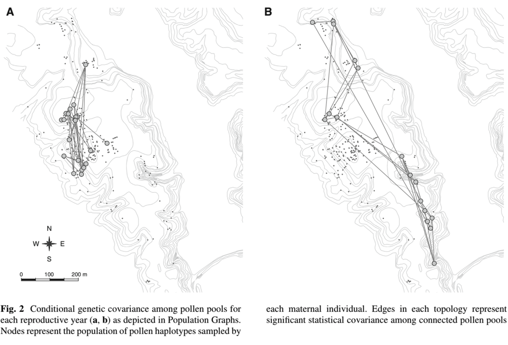

## Abstract

The manner by which pollinators move across a landscape and their resulting preferences and/or avoidances of travel through particular habitat types can have a significant impact on plant population genetic structure and population-level connectivity. We examined the spatial genetic structure of the understory tree Cornus florida (Cornaceae) adults (N-Adults = 452) and offspring (N-Offspring = 736) across two mating events to determine the extent to which pollen pool genetic covariance is influenced by intervening forest architecture. Resident adults showed no spatial partitioning but genotypes were positively autocorrelated up to a distance of 35 m suggesting a pattern of restricted seed dispersal. In the offspring, selfing rates were small (s(m) = 0.035) whereas both biparental inbreeding (s(b;open) (canopy) = 0.16, s(b;closed canopy) = 0.11) and correlated paternity (r(p;open canopy) = 0.21, r(p;closed canopy) = 0.07) were significantly influenced by primary canopy opening above individual mothers. The spatial distribution of genetic covariance in pollen pool composition was quantified for each reproductive event using Pollination Graphs, a network method based upon multivariate conditional genetic covariance. The georeferenced graph topology revealed a significant positive relationship between genetic covariance and pollinator movement through C. florida canopies, a negative relationship with open primary canopy (e. g., roads under open canopies and fields with no primary canopy), and no relationship with either conifer or mixed hardwood canopy species cover. These results suggest that both resident genetic structure within stands and genetic connectivity between sites in C. florida populations are influenced by spatial heterogeneity of mating individuals and quality of intervening canopy cover.